# Kaggle - Titanic Survival Problem

In this notebook, I will create a machine learning model to predict from given data if an individual will survive the titanic or not.

## Problem Statement:

*The sinking of the Titanic is one of the most infamous shipwrecks in history.*

*On April 15, 1912, during her maiden voyage, the widely considered “unsinkable” RMS Titanic sank after colliding with an iceberg. Unfortunately, there weren’t enough lifeboats for everyone onboard, resulting in the death of 1502 out of 2224 passengers and crew.*

*While there was some element of luck involved in surviving, it seems some groups of people were more likely to survive than others.*

*In this challenge, we ask you to build a predictive model that answers the question: “what sorts of people were more likely to survive?” using passenger data (ie name, age, gender, socio-economic class, etc).*

# Problem Approach

## Machine Learning Algorithms

This is a classification problem, as the outcome is either if someone survives (1) or not (0). This will limit our algorithms that we use.

For initial purposes, I will use the following algorithms:

- Logistic Regression
- SVC
- RandomForest
- K Nearest Neighbors
- Naive Bayes
- Decision Tree

## Stages of the Problem

The stages I will take to complete this analysis are:

- Importing the data
- Initial analysis to understand:
  - What information I have
  - What information is numerical, catogerical, ordinal or mixture
  - What information is missing
  - Find early indicators of correleation between the data
  - What features to drop
  - What features that require correcting
  - Do we need to create any features?
- Create a clean dataset with all the data being machine readable
- Split the data up into train and test
- Create machine learning model with the algorithms identified above
- Compare efficiencies of the algorithms
- Predict an outcome with the most efficient algorithm

# Data Analysis

## Initial Look

```python
'''
Import all the necessary libraries
'''

# data analysis
import numpy as np
import pandas as pd

# data visualisation
from matplotlib import pyplot as plt
import seaborn as sns

# machine learning and analysis
from sklearn.linear_model import LogisticRegression
from sklearn.svm import SVC
from sklearn.ensemble import RandomForestClassifier
from sklearn.neighbors import KNeighborsClassifier
from sklearn.naive_bayes import GaussianNB
from sklearn.tree import DecisionTreeClassifier
from sklearn.metrics import confusion_matrix
from sklearn.model_selection import train_test_split
```

First step is to import the data:

```python
train = pd.read_csv('train.csv')
test = pd.read_csv('test.csv')
fullset = [train, test]
```

Now that the data is imported, we can do some basic analysis on it to understand the dataset better. Let's start off by printing the columns of the training data, as well as the first few rows to get an idea of the data we have. In addition, I'll be running a command to see how many columns have 'NaN' values.

```python
print(train.columns.values)
```

```
['PassengerId' 'Survived' 'Pclass' 'Name' 'Sex' 'Age' 'SibSp' 'Parch'
 'Ticket' 'Fare' 'Cabin' 'Embarked']
```

```python
train.head()
```

|  | PassengerId | Survived | Pclass | Name | Sex | Age | SibSp | Parch | Ticket | Fare | Cabin | Embarked |
| --- | --- | --- | --- | --- | --- | --- | --- | --- | --- | --- | --- | --- |
| 0 | 1 | 0 | 3 | Braund, Mr. Owen Harris | male | 22.0 | 1 | 0 | A/5 21171 | 7.2500 | NaN | S |
| 1 | 2 | 1 | 1 | Cumings, Mrs. John Bradley (Florence Briggs Th... | female | 38.0 | 1 | 0 | PC 17599 | 71.2833 | C85 | C |
| 2 | 3 | 1 | 3 | Heikkinen, Miss. Laina | female | 26.0 | 0 | 0 | STON/O2. 3101282 | 7.9250 | NaN | S |
| 3 | 4 | 1 | 1 | Futrelle, Mrs. Jacques Heath (Lily May Peel) | female | 35.0 | 1 | 0 | 113803 | 53.1000 | C123 | S |
| 4 | 5 | 0 | 3 | Allen, Mr. William Henry | male | 35.0 | 0 | 0 | 373450 | 8.0500 | NaN | S |

```python
train.shape
```

```
(891, 12)
```

```python
test.shape
```

```
(418, 11)
```

```python
train['Name'].nunique()
```

```
891
```

```python
test['Name'].nunique()
```

```
418
```

```python
# null values for the training data
train_null_counts = train.isnull().sum()
train_null_counts[train_null_counts > 0].sort_values(ascending = False)
```

```
Cabin       687
Age         177
Embarked      2
dtype: int64
```

```python
# null values for the testing data
test_null_counts = test.isnull().sum()
test_null_counts[test_null_counts > 0].sort_values(ascending = False)
```

```
Cabin    327
Age       86
Fare       1
dtype: int64
```

Quite a few things can be taken away from the initial look at the data. Firstly, lets define the more ambiguous headings, which are outlined in Kaggle.

- **Pclass** - The ticket class the passenger was in (1st class, 2nd class or 3rd class)
- **SibSp** - The number of siblings / spouses aboard the Titanic
- **Parch** - The number of parents / children aboard the Titanic

Now lets look at the data more closely:

1. From the print of the data we can see that the data types are split accordingly:
   1. **Numerical Discrete**: PassengerID, SibSp, Parch
   2. **Numerical Continuous**: Age, Fare
   3. **Numerical Ordinal**: Survived, Pclass
   4. **Categorical**: Embarked, Sex, Name
   5. **Mixture of Categorical and Numerical**: Ticket, Cabin
2. The data columns that are categorical and numerical will need to be cleaned so that it is machine readable
3. For my initial analysis I'll be splitting the continuous data into bins
4. If we look at the total number of records, we have a total of *1309 passengers* (891 train and 418 test), or 99% of the passengers on board (excluding the crew)
5. Every name entry is unique - there are no duplicates. From initial analysis, either the name can be dropped, or we will need to find a commonality within the names
6. There are a large amount of null values for 'Cabin' for both train and test - either this column will need to be dropped (which is the more likely action given that *77%* of the information is missing), or a a method of filling in the gaps will need to be identified. However this is a mixture of categorical and numerical values, so a link will need to be identified if this is to be performed
7. There are a fair few null values in 'Age' which will need to be filled in - as this is a continuous value it will be easier to deal with than 'Cabin'

### Other Thoughts

1. There may be a relationship between having number of siblings/parents/spouses on board and suvival
2. We know most women and children survived, so there may be a link with survival depending on sex and age
3. People in 1st class may have been more likely to survive than 2nd class, and 2nd class more likely than 3rd class. This relationship should be explored.

## Exploring Initial Thoughts

As the Sex, SibSp (# of siblings), Parch (# of parents/spouses) and Pclass don't have null values, let's test my 3 points from the 'other thoughts' columns and have a quick look at the percentage that survived against those 3 criteria.

I'll be using the training data to analyse this as it has more data points.

```python
# percent that survived by number of siblings on board
train[['SibSp', 'Survived']].groupby(['SibSp'], as_index = False).mean().sort_values(by='Survived', ascending = False)
```

|  | SibSp | Survived |
| --- | --- | --- |
| 1 | 1 | 0.535885 |
| 2 | 2 | 0.464286 |
| 0 | 0 | 0.345395 |
| 3 | 3 | 0.250000 |
| 4 | 4 | 0.166667 |
| 5 | 5 | 0.000000 |
| 6 | 8 | 0.000000 |

```python
# percent that survived by number of parents/spouses on board
train[['Parch', 'Survived']].groupby(['Parch'], as_index = False).mean().sort_values(by='Survived', ascending = False)
```

|  | Parch | Survived |
| --- | --- | --- |
| 3 | 3 | 0.600000 |
| 1 | 1 | 0.550847 |
| 2 | 2 | 0.500000 |
| 0 | 0 | 0.343658 |
| 5 | 5 | 0.200000 |
| 4 | 4 | 0.000000 |
| 6 | 6 | 0.000000 |

```python
# percent that survived by sex
train[['Sex', 'Survived']].groupby(['Sex'], as_index = False).mean().sort_values(by='Survived', ascending = False)
```

|  | Sex | Survived |
| --- | --- | --- |
| 0 | female | 0.742038 |
| 1 | male | 0.188908 |

```python
# percent that survived by what class the passenger was in
train[['Pclass', 'Survived']].groupby(['Pclass'], as_index = False).mean().sort_values(by='Survived', ascending = False)
```

|  | Pclass | Survived |
| --- | --- | --- |
| 0 | 1 | 0.629630 |
| 1 | 2 | 0.472826 |
| 2 | 3 | 0.242363 |

From the pivot tables, we can see that the initial thoughts are in fact correct.

1. There is a correlation with survival depending on how many siblings and parents/spouses are on board. Although no obvious pattern can be distinguished from how the data currently is stored (as in the more siblings != higher chance of survival)
2. Women had a significantly higher chance of survival then men
3. Passengers in 1st class had a higher chance of survival than 2nd, and 2nd higher than 3rd class

I would like to analyse the chance of survival against age, however as the age values are continuous, until I sort them into bins, creating pivot tables will not be effective. As a result, let's visualise the ages in a histogram to see the age distribution that survived against those that didn't.

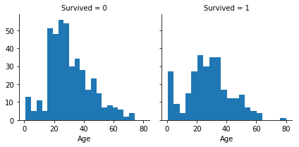

```python
age_hist = sns.FacetGrid(train, col='Survived')
age_hist.map(plt.hist, 'Age', bins=20)
```

From inital glance, it's not totally obvious if there is a strong correlation with age and survival. Kids seem to have survived more than died. The people in the ages of 20-40 had a mixture of survival and death, and there are a higher percentage of elderly that didn't survive.

To explore the age correlation a little bit more, lets compare age with sex and the passenger class to see if there is a more obvious correlation.

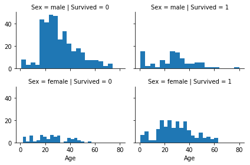

```python
# compare the sex and age against survival
sex_age_hist = sns.FacetGrid(train, col = 'Survived', row = 'Sex', height = 2, aspect = 1.5)
sex_age_hist.map(plt.hist, 'Age', bins = 20)
```

```python
# check the mean age of each sex
train[['Sex', 'Age']].groupby(['Sex'], as_index = False).mean().sort_values(by='Age', ascending = False)
```

|  | Sex | Age |
| --- | --- | --- |
| 1 | male | 30.726645 |
| 0 | female | 27.915709 |

From the histograms and table above we can see that age played a small role for men on the younger side i.e. younger boys were more likely to survive than any other age group. There is a peak in both graphs at around 30 years old for survival and death, this is explained by the mean age for men on the Titanic was approximately 31 years old.

For women we can see that on it's own age didn't really determine survival chances.

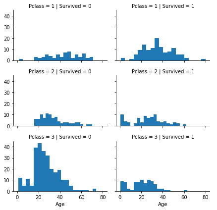

```python
# compare the Pclass and age against survival
pclass_age_hist = sns.FacetGrid(train, col='Survived', row='Pclass', height = 2, aspect = 1.5)
pclass_age_hist.map(plt.hist, 'Age', bins=20)
pclass_age_hist.add_legend()
```

```python
# check the mean age in each passenger class
train[['Pclass', 'Age']].groupby(['Pclass'], as_index = False).mean().sort_values(by='Age', ascending = False)
```

|  | Pclass | Age |
| --- | --- | --- |
| 0 | 1 | 38.233441 |
| 1 | 2 | 29.877630 |
| 2 | 3 | 25.140620 |

These graphs confirm that those in 1st class had a higher survival rate etc. but we can also see that those that were older had a higher chance of being in 1st class than if you were under 30. This might be due to the fact that older people have worked longer, therefore are further along in their careers and therefore could afford 1st class.

Another aspect that is worth exploring is to see is that in addition to sex and passenger class, was survival affected by where the passenger embarked.

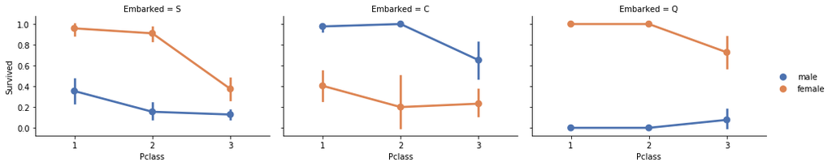

```python
age_gender_hist = sns.FacetGrid(train, col = 'Embarked', height = 3, aspect = 1.5)
age_gender_hist.map(sns.pointplot, 'Pclass', 'Survived', 'Sex', palette = 'deep')
age_gender_hist.add_legend()
```

From this, we can make the following observations:

- Women that embarked in Q, they were likely to survive regardless of passenger class
- It is a similar case with S until you get to 3rd class
- Men who embarked in C had a much higher chance of survival.
- Generally 3rd class had a lower rate of survival for both sexes

We can conclude that where a person embarked had an influence on their survival.

1st class tickets are generally more expensive than 2nd class tickets, and 2nd class more expensive than 3rd class. Lets look at the survival of people by the fare they paid and where they embarked.

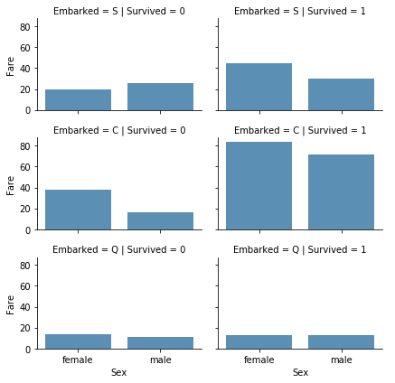

```python
fare_hist = sns.FacetGrid(train, row='Embarked', col='Survived', height=2, aspect=1.5)
fare_hist.map(sns.barplot, 'Sex', 'Fare', alpha=0.8, ci=None)
fare_hist.add_legend()
```

From this we can conclude that those who paid more generally had a higher chance of survival.

One last thing to look at is the 'Ticket' parameter. As previously seen, it doesn't have any null values. Lets see if all the values are unique.

```python
train['Ticket'].nunique()
```

```
681
```

```python
test['Ticket'].nunique()
```

```
363
```

## Removing and Consolidating Data

Now that we have the initial analysis done, we can start to remove data and making the data machine readable.

### Ticket and Cabin Column

First of all, lets remove the Ticket and Cabin data. I will also remove 'PassengerID' as that is an index that won't be contributing to the survival of a passenger.

```python
train = train.drop(['Ticket', 'Cabin', 'PassengerId'], axis = 1)
test = test.drop(['Ticket', 'Cabin', 'PassengerId'], axis = 1)
fullset = [train, test]
```

### Name Column

The next column that might be worth dropping is name. However in each name, there is 1 consistency - the title. If we look at the first 10 entries of the training data we can see the titles of each name.

```python
train.head(10)
```

|  | Survived | Pclass | Name | Sex | Age | SibSp | Parch | Fare | Embarked |
| --- | --- | --- | --- | --- | --- | --- | --- | --- | --- |
| 0 | 0 | 3 | Braund, Mr. Owen Harris | male | 22.0 | 1 | 0 | 7.2500 | S |
| 1 | 1 | 1 | Cumings, Mrs. John Bradley (Florence Briggs Th... | female | 38.0 | 1 | 0 | 71.2833 | C |
| 2 | 1 | 3 | Heikkinen, Miss. Laina | female | 26.0 | 0 | 0 | 7.9250 | S |
| 3 | 1 | 1 | Futrelle, Mrs. Jacques Heath (Lily May Peel) | female | 35.0 | 1 | 0 | 53.1000 | S |
| 4 | 0 | 3 | Allen, Mr. William Henry | male | 35.0 | 0 | 0 | 8.0500 | S |
| 5 | 0 | 3 | Moran, Mr. James | male | NaN | 0 | 0 | 8.4583 | Q |
| 6 | 0 | 1 | McCarthy, Mr. Timothy J | male | 54.0 | 0 | 0 | 51.8625 | S |
| 7 | 0 | 3 | Palsson, Master. Gosta Leonard | male | 2.0 | 3 | 1 | 21.0750 | S |
| 8 | 1 | 3 | Johnson, Mrs. Oscar W (Elisabeth Vilhelmina Berg) | female | 27.0 | 0 | 2 | 11.1333 | S |
| 9 | 1 | 2 | Nasser, Mrs. Nicholas (Adele Achem) | female | 14.0 | 1 | 0 | 30.0708 | C |

Here we can see the titles are:

- Mr
- Mrs
- Miss
- Master This is a commonality that will be worth exploring against survival. Let's extract the titles from each name. To do this, we will need to use **regular expressions** to identify the title part.

Lets create a new column called 'Title' where the title of the name is extracted from the name.

```python
for dataset in fullset:
    dataset['Title'] = dataset.Name.str.extract(' ([A-Za-z]+)\.', expand=False)
```

```python
train['Title'].value_counts()
```

```
Mr          517
Miss        182
Mrs         125
Master       40
Dr            7
Rev           6
Mlle          2
Major         2
Col           2
Capt          1
Ms            1
Jonkheer      1
Sir           1
Don           1
Mme           1
Countess      1
Lady          1
Name: Title, dtype: int64
```

```python
test['Title'].value_counts()
```

```
Mr        240
Miss       78
Mrs        72
Master     21
Col         2
Rev         2
Dr          1
Dona        1
Ms          1
Name: Title, dtype: int64
```

Here we can see that there are a large amount of individuals with the titles 'Mr', 'Miss', 'Mrs' and 'Master'. The other titles are more uncommon/rare or a variation of the top 4. In order to remove the amount of variation in the titles, lets replace the rare titles with 'Rare'.

Other titles to replace are:

- Mlle and Ms are both a variation of Miss
- MMe is a variation of Mrs

```python
for dataset in fullset:
    dataset['Title'] = dataset['Title'].replace(['Lady', 'Countess', 'Capt', 'Col', \
           'Don', 'Dr', 'Major', 'Rev', 'Sir', 'Jonkheer', 'Dona'], 'Rare')

    dataset['Title'] = dataset['Title'].replace('Mlle', 'Miss')
    dataset['Title'] = dataset['Title'].replace('Ms', 'Miss')
    dataset['Title'] = dataset['Title'].replace('Mme', 'Mrs')
```

```python
train['Title'].value_counts()
```

```
Mr        517
Miss      185
Mrs       126
Master     40
Rare       23
Name: Title, dtype: int64
```

```python
test['Title'].value_counts()
```

```
Mr        240
Miss       79
Mrs        72
Master     21
Rare        6
Name: Title, dtype: int64
```

Now the title column is much more organised and easier to manage. We can now remove the 'Name' column.

```python
train = train.drop(['Name'], axis = 1)
test = test.drop(['Name'], axis = 1)
fullset = [train, test]
```

Now that the 'Title' field is extracted from the 'Name' field, lets see if there is any correlation between survival and the title an individual had.

```python
train[['Title', 'Survived']].groupby(['Title'], as_index = False).mean().sort_values(by='Survived', ascending = False)
```

|  | Title | Survived |
| --- | --- | --- |
| 3 | Mrs | 0.793651 |
| 1 | Miss | 0.702703 |
| 0 | Master | 0.575000 |
| 4 | Rare | 0.347826 |
| 2 | Mr | 0.156673 |

Here we can see that married women had the highest chance of survival, followed by unmarried womena and young boys. There is a correlation with title and survival.

Now that we have made some changes and dropped data, lets have a quick look at how the data looks now:

```python
train.head(10)
```

|  | Survived | Pclass | Sex | Age | SibSp | Parch | Fare | Embarked | Title |
| --- | --- | --- | --- | --- | --- | --- | --- | --- | --- |
| 0 | 0 | 3 | male | 22.0 | 1 | 0 | 7.2500 | S | Mr |
| 1 | 1 | 1 | female | 38.0 | 1 | 0 | 71.2833 | C | Mrs |
| 2 | 1 | 3 | female | 26.0 | 0 | 0 | 7.9250 | S | Miss |
| 3 | 1 | 1 | female | 35.0 | 1 | 0 | 53.1000 | S | Mrs |
| 4 | 0 | 3 | male | 35.0 | 0 | 0 | 8.0500 | S | Mr |
| 5 | 0 | 3 | male | NaN | 0 | 0 | 8.4583 | Q | Mr |
| 6 | 0 | 1 | male | 54.0 | 0 | 0 | 51.8625 | S | Mr |
| 7 | 0 | 3 | male | 2.0 | 3 | 1 | 21.0750 | S | Master |
| 8 | 1 | 3 | female | 27.0 | 0 | 2 | 11.1333 | S | Mrs |
| 9 | 1 | 2 | female | 14.0 | 1 | 0 | 30.0708 | C | Mrs |

The following things still need to be done:

- Age:
  - Fill in any null values
  - Put the values into bins
  - Encode the bins
- Sex:
  - Encode the values so that it is machine readable
- Fare:
  - Fill in any null values
  - Put the values into bins
  - Encode the bins
- Embarked:
  - Fill in null values
  - Encode the values
- SibSp and Parch:
  - Explore relationship further between the survival and having a sibling/parent/spouse on board to see if these columns can be dropped or if they are relevant.

Lets look at the data with the Siblings and Parents being on board.

## Siblings and Parents Analysis

Looking at the 7th record on the table above, we can see this passengar had 3 siblings and 1 parent/spouse onboard. Altogether that makes a family size of **5**, and this passenger did not survive. The next record had 2 parents onboard, a family size of 3, and survived. Lets add the siblings and parents together into a new column called 'FamilySize' and see the correlation with survival.

```python
for dataset in fullset:
    dataset['FamilySize'] = dataset['SibSp'] + dataset['Parch'] + 1
```

```python
train[['FamilySize', 'Survived']].groupby(['FamilySize'], as_index = False).mean().sort_values(by = 'Survived', ascending = False)
```

|  | FamilySize | Survived |
| --- | --- | --- |
| 3 | 4 | 0.724138 |
| 2 | 3 | 0.578431 |
| 1 | 2 | 0.552795 |
| 6 | 7 | 0.333333 |
| 0 | 1 | 0.303538 |
| 4 | 5 | 0.200000 |
| 5 | 6 | 0.136364 |
| 7 | 8 | 0.000000 |
| 8 | 11 | 0.000000 |

Not being alone seems to be increasing the chances of survival, however more family members than 4 seems to decrease chances of survival (with the anomaly of 7 family members which has similar survival rate as being alone). Lets have a look at the survival rates of if you are alone vs not alone, and survival rates of having a family larger than 4 or smaller than 4.

```python
for dataset in fullset:
    dataset['IsAlone'] = 0
    dataset.loc[dataset['FamilySize'] == 1, 'IsAlone'] = 1
```

```python
train[['IsAlone', 'Survived']].groupby(['IsAlone'], as_index = False).mean().sort_values(by = 'Survived', ascending = False)
```

|  | IsAlone | Survived |
| --- | --- | --- |
| 0 | 0 | 0.505650 |
| 1 | 1 | 0.303538 |

```python
for dataset in fullset:
    dataset['LargerThanFour'] = 0
    dataset.loc[ dataset['FamilySize'] <= 4, 'LargerThanFour'] = 0
    dataset.loc[ dataset['FamilySize'] > 4, 'LargerThanFour'] = 1
    dataset['LargerThanFour'] = dataset['LargerThanFour'].astype(int)
```

```python
train[['LargerThanFour', 'Survived']].groupby(['LargerThanFour'], as_index = False).mean().sort_values(by = 'Survived', ascending = False)
```

|  | LargerThanFour | Survived |
| --- | --- | --- |
| 0 | 0 | 0.400483 |
| 1 | 1 | 0.161290 |

```python
# removing the solo passengers from being included in the 'Larger than four' bin to remove the bias of low survival from being a solo passenger
for dataset in fullset:
    dataset['LargerThanFour'] = 0
    dataset.loc[ dataset['FamilySize'] == 1, 'LargerThanFour'] = 0
    dataset.loc[(dataset['FamilySize'] > 1) & (dataset['FamilySize'] <= 4), 'LargerThanFour'] = 1
    dataset.loc[ dataset['FamilySize'] > 4, 'LargerThanFour'] = 2
    dataset['LargerThanFour'] = dataset['LargerThanFour'].astype(int)
```

```python
train[['LargerThanFour', 'Survived']].groupby(['LargerThanFour'], as_index = False).mean().sort_values(by = 'Survived', ascending = False)
```

|  | LargerThanFour | Survived |
| --- | --- | --- |
| 1 | 1 | 0.578767 |
| 0 | 0 | 0.303538 |
| 2 | 2 | 0.161290 |

Here we can see that being alone meant that you were less likely to survive. However, having a family larger than 4 also meant that you were less likely to survive. Having a binary column that indicated whether a family had 4 members or not ignore the low possibility of survival when you're alone, as seen in the first test of 'IsAlone'. If we remove the solo passengers from the 'Is the family larger than 4', we can see the survival rate of families with 2-4 members is over half. If the passenger had a family more than 4 members, they had a much lower survival rate.

Now that we have sorted the 'SibSp' and 'Parch' columns, we can remove those, along with the new columns created that we won't need: 'FamilySize', 'IsAlone'.

```python
# double check the headings are as I would expect them to be
train.head()
```

|  | Survived | Pclass | Sex | Age | SibSp | Parch | Fare | Embarked | Title | FamilySize | IsAlone | LargerThanFour |
| --- | --- | --- | --- | --- | --- | --- | --- | --- | --- | --- | --- | --- |
| 0 | 0 | 3 | male | 22.0 | 1 | 0 | 7.2500 | S | Mr | 2 | 0 | 1 |
| 1 | 1 | 1 | female | 38.0 | 1 | 0 | 71.2833 | C | Mrs | 2 | 0 | 1 |
| 2 | 1 | 3 | female | 26.0 | 0 | 0 | 7.9250 | S | Miss | 1 | 1 | 0 |
| 3 | 1 | 1 | female | 35.0 | 1 | 0 | 53.1000 | S | Mrs | 2 | 0 | 1 |
| 4 | 0 | 3 | male | 35.0 | 0 | 0 | 8.0500 | S | Mr | 1 | 1 | 0 |

```python
train = train.drop(['Parch', 'SibSp', 'FamilySize', 'IsAlone'], axis = 1)
test = test.drop(['Parch', 'SibSp', 'FamilySize', 'IsAlone'], axis = 1)
fullset = [train, test]
```

```python
# double check if everything went as planned
train.head()
```

|  | Survived | Pclass | Sex | Age | Fare | Embarked | Title | LargerThanFour |
| --- | --- | --- | --- | --- | --- | --- | --- | --- |
| 0 | 0 | 3 | male | 22.0 | 7.2500 | S | Mr | 1 |
| 1 | 1 | 1 | female | 38.0 | 71.2833 | C | Mrs | 1 |
| 2 | 1 | 3 | female | 26.0 | 7.9250 | S | Miss | 0 |
| 3 | 1 | 1 | female | 35.0 | 53.1000 | S | Mrs | 1 |
| 4 | 0 | 3 | male | 35.0 | 8.0500 | S | Mr | 0 |

## Filling in Null Values for Age and Binning the Values

Now lets deal with filling in the null values and putting the ages into bins.

There are a few ways to deal with null values for continuous numerical data:

1. Generate random numbers from standard deviation and mean
2. Guess the missing values from other values from the data (like finding mean age from Gender and PClass and using that to fill in the missing values)
3. Do a bit of both

I will do method 2, as method 1 and 3 ultimately adds an element of randomness in the data which I want to avoid. To do this, I will need to encode the 'Sex' column, so that I can easily compare sex and passenger class to get a median age.

In my **initial** analysis for categorical values I will encode using ordinal values specified manually. In a later analysis I will use OneHotEncoding to explore the effects it has on accuracy.

```python
# convert the genders into 0 and 1
for dataset in fullset:
    dataset['Sex'] = dataset['Sex'].map( {'female' : 1, 'male': 0}).astype(int)
```

```python
train.head(10)
```

|  | Survived | Pclass | Sex | Age | Fare | Embarked | Title | LargerThanFour |
| --- | --- | --- | --- | --- | --- | --- | --- | --- |
| 0 | 0 | 3 | 0 | 22.0 | 7.2500 | S | Mr | 1 |
| 1 | 1 | 1 | 1 | 38.0 | 71.2833 | C | Mrs | 1 |
| 2 | 1 | 3 | 1 | 26.0 | 7.9250 | S | Miss | 0 |
| 3 | 1 | 1 | 1 | 35.0 | 53.1000 | S | Mrs | 1 |
| 4 | 0 | 3 | 0 | 35.0 | 8.0500 | S | Mr | 0 |
| 5 | 0 | 3 | 0 | NaN | 8.4583 | Q | Mr | 0 |
| 6 | 0 | 1 | 0 | 54.0 | 51.8625 | S | Mr | 0 |
| 7 | 0 | 3 | 0 | 2.0 | 21.0750 | S | Master | 2 |
| 8 | 1 | 3 | 1 | 27.0 | 11.1333 | S | Mrs | 1 |
| 9 | 1 | 2 | 1 | 14.0 | 30.0708 | C | Mrs | 1 |

```python
# using Pclass and Gender, we can guess ages
# create an empty array to hold the output values of the median ages
guess_ages = np.zeros((2,3))

# run a for loop that calculates the median age of the average male and female in
# Pclass 1, 2 and 3, and then replace the missing ages
for dataset in fullset:
    for i in range(0, 2):
        for j in range(0, 3):
            guess_df = dataset[(dataset['Sex'] == i) & \
                                  (dataset['Pclass'] == j+1)]['Age'].dropna()

            age_guess = guess_df.median()

            # Convert random age float to nearest .5 age
            guess_ages[i,j] = int( age_guess/0.5 + 0.5 ) * 0.5

    # go through the data and check Pclass and Gender, then fill in the age if it is a null value accordingly
    for i in range(0, 2):
        for j in range(0, 3):
            dataset.loc[ (dataset.Age.isnull()) & (dataset.Sex == i) & (dataset.Pclass == j+1),\
                    'Age'] = guess_ages[i,j]

    dataset['Age'] = dataset['Age'].astype(int)
```

```python
train.head(10)
```

|  | Survived | Pclass | Sex | Age | Fare | Embarked | Title | LargerThanFour |
| --- | --- | --- | --- | --- | --- | --- | --- | --- |
| 0 | 0 | 3 | 0 | 22 | 7.2500 | S | Mr | 1 |
| 1 | 1 | 1 | 1 | 38 | 71.2833 | C | Mrs | 1 |
| 2 | 1 | 3 | 1 | 26 | 7.9250 | S | Miss | 0 |
| 3 | 1 | 1 | 1 | 35 | 53.1000 | S | Mrs | 1 |
| 4 | 0 | 3 | 0 | 35 | 8.0500 | S | Mr | 0 |
| 5 | 0 | 3 | 0 | 25 | 8.4583 | Q | Mr | 0 |
| 6 | 0 | 1 | 0 | 54 | 51.8625 | S | Mr | 0 |
| 7 | 0 | 3 | 0 | 2 | 21.0750 | S | Master | 2 |
| 8 | 1 | 3 | 1 | 27 | 11.1333 | S | Mrs | 1 |
| 9 | 1 | 2 | 1 | 14 | 30.0708 | C | Mrs | 1 |

We can see that row 5, that originally had a null value, now has the age 25 in. Now lets start binning the ages into 5 bins. To work out how the ages should be split up, we will use the pandas function 'cut'.

```python
train['AgeBand'] = pd.cut(train['Age'], 5)
```

```python
train[['AgeBand', 'Survived']].groupby(['AgeBand'], as_index=False).mean().sort_values(by='AgeBand', ascending=True)
```

|  | AgeBand | Survived |
| --- | --- | --- |
| 0 | (-0.08, 16.0] | 0.550000 |
| 1 | (16.0, 32.0] | 0.337374 |
| 2 | (32.0, 48.0] | 0.412037 |
| 3 | (48.0, 64.0] | 0.434783 |
| 4 | (64.0, 80.0] | 0.090909 |

Here we can see that the age bands are split into groups of 16. Lets now encode the data as per the bins.

```python
for dataset in fullset:
    dataset.loc[ dataset['Age'] <= 16, 'Age'] = 0
    dataset.loc[(dataset['Age'] > 16) & (dataset['Age'] <= 32), 'Age'] = 1
    dataset.loc[(dataset['Age'] > 32) & (dataset['Age'] <= 48), 'Age'] = 2
    dataset.loc[(dataset['Age'] > 48) & (dataset['Age'] <= 64), 'Age'] = 3
    dataset.loc[ dataset['Age'] > 64, 'Age']
```

```python
train.head()
```

|  | Survived | Pclass | Sex | Age | Fare | Embarked | Title | LargerThanFour | AgeBand |
| --- | --- | --- | --- | --- | --- | --- | --- | --- | --- |
| 0 | 0 | 3 | 0 | 1 | 7.2500 | S | Mr | 1 | (16.0, 32.0] |
| 1 | 1 | 1 | 1 | 2 | 71.2833 | C | Mrs | 1 | (32.0, 48.0] |
| 2 | 1 | 3 | 1 | 1 | 7.9250 | S | Miss | 0 | (16.0, 32.0] |
| 3 | 1 | 1 | 1 | 2 | 53.1000 | S | Mrs | 1 | (32.0, 48.0] |
| 4 | 0 | 3 | 0 | 2 | 8.0500 | S | Mr | 0 | (32.0, 48.0] |

```python
train = train.drop(['AgeBand'], axis=1)
fullset = [train, test]
train.head()
```

|  | Survived | Pclass | Sex | Age | Fare | Embarked | Title | LargerThanFour |
| --- | --- | --- | --- | --- | --- | --- | --- | --- |
| 0 | 0 | 3 | 0 | 1 | 7.2500 | S | Mr | 1 |
| 1 | 1 | 1 | 1 | 2 | 71.2833 | C | Mrs | 1 |
| 2 | 1 | 3 | 1 | 1 | 7.9250 | S | Miss | 0 |
| 3 | 1 | 1 | 1 | 2 | 53.1000 | S | Mrs | 1 |
| 4 | 0 | 3 | 0 | 2 | 8.0500 | S | Mr | 0 |

## Encoding Fares

We will be treating the 'Fare' column the same as the 'Age' column. As identified early on, the test dataset has a null value for 'Fare'. As it is a solo value.

```python
# calculate the median fare value
test.Fare.dropna().median()
```

```
14.4542
```

```python
dataset['Fare'] = dataset['Fare'].fillna(14.452)
```

```python
# run the test again to ensure that there are no null values for 'Fare' in the test data. Should return an empty Series
test_null_counts = test.isnull().sum()
test_null_counts[test_null_counts > 0].sort_values(ascending = False)
```

```
Series([], dtype: int64)
```

```python
# create FareBand using pandas
train['FareBand'] = pd.qcut(train['Fare'], 4)
train[['FareBand', 'Survived']].groupby(['FareBand'], as_index = False).mean().sort_values(by='FareBand', ascending=True)
```

|  | FareBand | Survived |
| --- | --- | --- |
| 0 | (-0.001, 7.91] | 0.197309 |
| 1 | (7.91, 14.454] | 0.303571 |
| 2 | (14.454, 31.0] | 0.454955 |
| 3 | (31.0, 512.329] | 0.581081 |

```python
# encode the 'Fare' values
for dataset in fullset:
    dataset.loc[ dataset['Fare'] <= 7.91, 'Fare'] = 0
    dataset.loc[(dataset['Fare'] > 7.91) & (dataset['Fare'] <= 14.454), 'Fare'] = 1
    dataset.loc[(dataset['Fare'] > 14.454) & (dataset['Fare'] <= 31), 'Fare'] = 2
    dataset.loc[ dataset['Fare'] > 31, 'Fare'] = 3
    dataset['Fare'] = dataset['Fare'].astype(int)
```

```python
train = train.drop(['FareBand'], axis = 1)
fullset = [train, test]
```

```python
# check everything is ok
train.head()
```

|  | Survived | Pclass | Sex | Age | Fare | Embarked | Title | LargerThanFour |
| --- | --- | --- | --- | --- | --- | --- | --- | --- |
| 0 | 0 | 3 | 0 | 1 | 0 | S | Mr | 1 |
| 1 | 1 | 1 | 1 | 2 | 3 | C | Mrs | 1 |
| 2 | 1 | 3 | 1 | 1 | 1 | S | Miss | 0 |
| 3 | 1 | 1 | 1 | 2 | 3 | S | Mrs | 1 |
| 4 | 0 | 3 | 0 | 2 | 1 | S | Mr | 0 |

## Filling in Null values with 'Embarked' and Encoding

As identified earlier, the training data for 'Embarked' had 2 null values. As it is only 2 values, I will deal with them by filling them in with the most common value that occurs, then encode the information.

```python
train.Embarked.dropna().mode()[0]
```

```
'S'
```

```python
for dataset in fullset:
    dataset['Embarked'] = dataset['Embarked'].fillna('S')
```

```python
# encode the column
for dataset in fullset:
    dataset['Embarked'] = dataset['Embarked'].map({'S':0, 'C':1, 'Q':2}).astype(int)
```

```python
train.head()
```

|  | Survived | Pclass | Sex | Age | Fare | Embarked | Title | LargerThanFour |
| --- | --- | --- | --- | --- | --- | --- | --- | --- |
| 0 | 0 | 3 | 0 | 1 | 0 | 0 | Mr | 1 |
| 1 | 1 | 1 | 1 | 2 | 3 | 1 | Mrs | 1 |
| 2 | 1 | 3 | 1 | 1 | 1 | 0 | Miss | 0 |
| 3 | 1 | 1 | 1 | 2 | 3 | 0 | Mrs | 1 |
| 4 | 0 | 3 | 0 | 2 | 1 | 0 | Mr | 0 |

## Encoding 'Title'

Finally, we can encode the 'Title' column. Then we will be ready to start creating prediction models.

```python
title_mapping = {"Mr": 1, "Miss": 2, "Mrs": 3, "Master": 4, "Rare": 5}
for dataset in fullset:
    dataset['Title'] = dataset['Title'].map(title_mapping)
```

```python
train.head()
```

|  | Survived | Pclass | Sex | Age | Fare | Embarked | Title | LargerThanFour |
| --- | --- | --- | --- | --- | --- | --- | --- | --- |
| 0 | 0 | 3 | 0 | 1 | 0 | 0 | 1 | 1 |
| 1 | 1 | 1 | 1 | 2 | 3 | 1 | 3 | 1 |
| 2 | 1 | 3 | 1 | 1 | 1 | 0 | 2 | 0 |
| 3 | 1 | 1 | 1 | 2 | 3 | 0 | 3 | 1 |
| 4 | 0 | 3 | 0 | 2 | 1 | 0 | 1 | 0 |

# Modeling and Predicting

Now that we have the data cleaned and ready, we can run the data through the machine learning algorithms.

As a reminder, the algorithms I'll be using are as follows:

1. Logistic Regression
2. K-Nearest Neighbours
3. Support Vector Machine
4. Naive Bayes
5. Decision Tree Classification
6. Random Forest Classification

For my **initial** analysis I will not be adjusting many parameters of the algorithms. After my initial prediction, I will be adjusting parameters to improve the model.

```python
# create dataframe that logs accuracy of the different models
model_accuracy = pd.DataFrame(columns=['Model Name', 'Accuracy'])
```

```python
# Split the data up into train X and Y
X = train.drop(['Survived'], axis = 1)
y = train['Survived']
X_train, X_test, y_train, y_test = train_test_split(X, y, test_size = 0.25, random_state = 0)
```

```python
# check how many tests there are
X_test.shape
```

```
(223, 7)
```

```python
# create variable for testing efficiency
total_tests = 223
```

```python
# logistic regression
logreg = LogisticRegression()
logreg.fit(X_train, y_train)
Y_regpred = logreg.predict(X_test)
regpred_conmat = confusion_matrix(y_test, Y_regpred)
regpred_correct = regpred_conmat[0,0] + regpred_conmat[1,1]
regpred_acc = regpred_correct/total_tests
model_accuracy = model_accuracy.append({'Model Name': 'Logistic Regression', 'Accuracy': regpred_acc}, ignore_index = True)
```

```python
# svc
svc_mod = SVC()
svc_mod.fit(X_train, y_train)
Y_svcpred = svc_mod.predict(X_test)
svc_conmat = confusion_matrix(y_test, Y_svcpred)
svc_correct = svc_conmat[0,0] + svc_conmat[1,1]
svc_mod_acc = (svc_correct/total_tests)
model_accuracy = model_accuracy.append({'Model Name': 'SVC', 'Accuracy': svc_mod_acc}, ignore_index = True)
```

```python
# random forest classifier
RFC = RandomForestClassifier()
RFC.fit(X_train, y_train)
Y_RFC = RFC.predict(X_test)
RFC_conmat = confusion_matrix(y_test, Y_RFC)
RFC_correct = RFC_conmat[0,0] + RFC_conmat[1,1]
RFC_acc = (RFC_correct/total_tests)
model_accuracy = model_accuracy.append({'Model Name': 'Random Forrest Classifer', 'Accuracy': RFC_acc}, ignore_index = True)
```

```python
# K Nearest Classifier
knn = KNeighborsClassifier()
knn.fit(X_train, y_train)
Y_knn = knn.predict(X_test)
knn_conmat = confusion_matrix(y_test, Y_knn)
knn_correct = knn_conmat[0,0] + knn_conmat[1,1]
knn_acc = (knn_correct/total_tests)
model_accuracy = model_accuracy.append({'Model Name': 'K Neighbors Classifier', 'Accuracy': knn_acc}, ignore_index = True)
```

```python
# Naive Bayes
gnb = GaussianNB()
gnb.fit(X_train, y_train)
Y_gnb = gnb.predict(X_test)
gnb_conmat = confusion_matrix(y_test, Y_gnb)
gnb_correct = gnb_conmat[0,0] + gnb_conmat[1,1]
gnb_acc = (gnb_correct/total_tests)
model_accuracy = model_accuracy.append({'Model Name': 'GaussianNB', 'Accuracy': gnb_acc}, ignore_index = True)
```

```python
# Decision tree
Dtree = DecisionTreeClassifier()
Dtree.fit(X_train, y_train)
Y_Dtree = Dtree.predict(X_test)
Dtree_conmat = confusion_matrix(y_test, Y_Dtree)
Dtree_correct = Dtree_conmat[0,0] + Dtree_conmat[1,1]
Dtree_acc = (Dtree_correct/total_tests)
model_accuracy = model_accuracy.append({'Model Name': 'Decision Tree Classifier', 'Accuracy': Dtree_acc}, ignore_index = True)
```

```python
model_accuracy.sort_values(by = 'Accuracy', ascending = False)
```

|  | Model Name | Accuracy |
| --- | --- | --- |
| 5 | Decision Tree Classifier | 0.838565 |
| 2 | Random Forrest Classifer | 0.834081 |
| 3 | K Neighbors Classifier | 0.825112 |
| 1 | SVC | 0.811659 |
| 0 | Logistic Regression | 0.775785 |
| 4 | GaussianNB | 0.762332 |

Here we can see that the most accurate model is the Decision Tree Classifier with an accuracy of 84%. As this is the highest accuracy of all the models, the prediction will be made using this model.

# Initial Kaggle Submission

Using the data above and the Decision Tree Classifier, the Kaggle submission came back with the accuracy of **78.9%**. This placed me in position **3566** out of 16650 entrants (at the time of writing).

## How can the model be improved?

There are a few things to be explored to improve the model:

- Does OneHotEncoding make a difference to the output?
  - With the current setup, the model might consider the weight of a female higher than a male as female = 1 and male = 0.
- Does adjusting the parameters within the algorithms reach a better accuracy?
- Will XGBoost improve accuracy?
- A combnation of the most accurate models might produce a better model
- Training the model using K-Fold Cross Validation